# Capstone Implementation Report 1

Keerthi/Aarushi/Velenta

13 April 2016

**Tasks in progress**

1. Mapping of crime data from the year 2008-2016 using longitude and lattitude to chicago Zip codes. For the data before 2008, lonitude and lattitude are not available.
2. Demographic data download from ‘SocialExplorer’ is complete. One of the challenge is that only 5 year estimates are available (not yearly). Data downloaded for the period 2010-2014 at zip code level. Challenge being Zip code filter not available for the period 2005-2009. Hence mapping from census tract to zipcode is required and is in progress.
3. Created Yearly and Monthly Time series for business enteries and business exits from the Business Licenses data source. Analysis in progres to identify the right p,d,q,P,D,Q paramter for both the TS. Next steps is to build a cointegration model.
4. Analysis of ‘business entries plus active’ in progress.
5. Analysis of economic factors to analyze the peaks in the Entry and exit time series, as seen from the below plots.
6. Data preparation for Age of business model is in progress.

**TIME SERIES ANALYSIS REPORT**

```r
library(tseries)
library(forecast)
```

**Yearly TS analysis**

Read in the Yearly Business Enrty and Exit files

```r
datapath <- "C:/Users/Keerthi/Desktop/Uchicago2015/Capstone/Data"
Yearly.Entry.data <- read.csv(file=paste(datapath,"EntryYearlyData.csv",sep="/"),
                              header=TRUE,sep=",")
Yearly.Exit.data <- read.csv(file=paste(datapath,"ExitYearlyData.csv",sep="/"),
                              header=TRUE,sep=",")
head(Yearly.Entry.data)
```

```
##   Year Business.Entry
## 1 1996             28
## 2 1997             19
## 3 1998             37
## 4 1999             28
## 5 2000             82
## 6 2001           1698
```

```r
head(Yearly.Exit.data)
```

```
##   Year Business.Exit
## 1 1997            22
## 2 1998            13
## 3 1999            14
## 4 2000             5
## 5 2001            30
## 6 2002           412
```

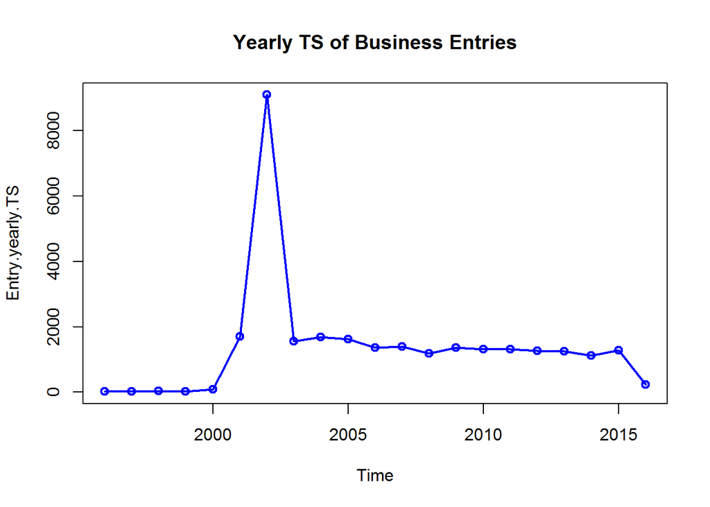

```r
Entry.yearly.TS <- ts(Yearly.Entry.data$Business.Entry,start = 1996,frequency = 1)
Exit.yearly.TS <- ts(Yearly.Exit.data$Business.Exit,start = 1997,frequency = 1)
plot(Entry.yearly.TS,type="o",col="blue",lwd=2,main="Yearly TS of Business Entries")
```

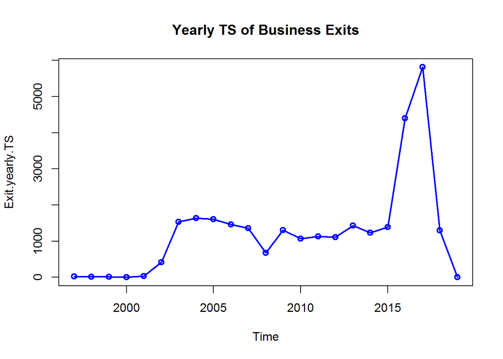

```r
plot(Exit.yearly.TS,type="o",col="blue",lwd=2,main="Yearly TS of Business Exits")
```

ACF and PACF plots

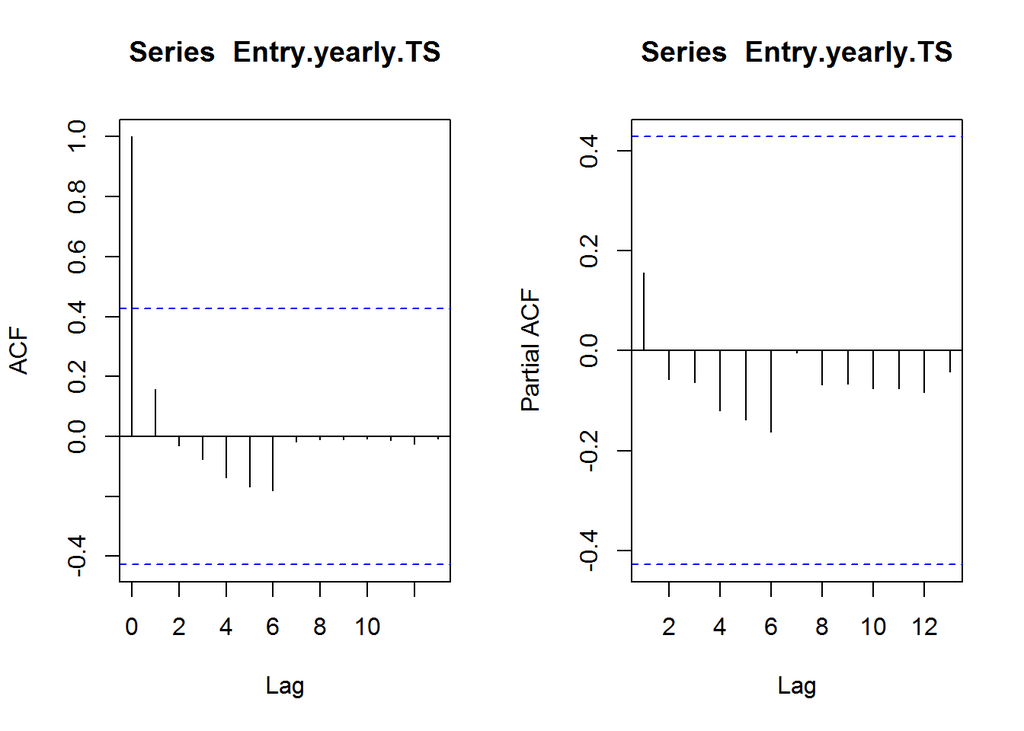

```r
par(mfrow=c(1,2))
acf(Entry.yearly.TS)
pacf(Entry.yearly.TS)
```

```r
adf.test(Entry.yearly.TS)
```

```
##
##  Augmented Dickey-Fuller Test
##
## data:  Entry.yearly.TS
## Dickey-Fuller = -2.4182, Lag order = 2, p-value = 0.4131
## alternative hypothesis: stationary
```

P-value returned from adf.test is 0.4131 which is greater than significance level of 0.01 and 0.05. Hence we cannot reject the null hypothesis that the series is a unit root. Business entry TS is non-stationary

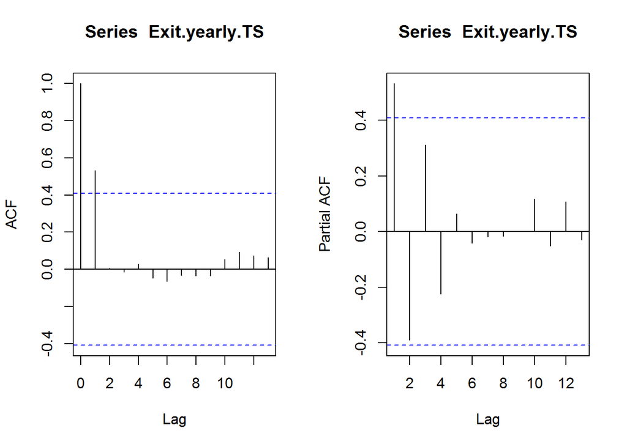

```r
par(mfrow=c(1,2))
acf(Exit.yearly.TS)
pacf(Exit.yearly.TS)
```

```r
adf.test(Exit.yearly.TS)
```

```
##
##  Augmented Dickey-Fuller Test
##
## data:  Exit.yearly.TS
## Dickey-Fuller = -1.4504, Lag order = 2, p-value = 0.7817
## alternative hypothesis: stationary
```

P-value is 0.7817 which is greater than the significance level of 0.01 and 0.05. We can conclude that Business Exit TS is non-stationary.

```r
auto.arima(Entry.yearly.TS)
```

```
## Series: Entry.yearly.TS
## ARIMA(0,0,0) with non-zero mean
##
## Coefficients:
##       intercept
##       1379.4762
## s.e.   399.3484
##
## sigma^2 estimated as 3349046:  log likelihood=-187.55
## AIC=379.1   AICc=379.77   BIC=381.19
```

```r
auto.arima(Exit.yearly.TS)
```

```
## Series: Exit.yearly.TS
## ARIMA(0,1,0)
##
## sigma^2 estimated as 1621369:  log likelihood=-188.5
## AIC=379.01   AICc=379.21   BIC=380.1
```

Auto.arima() suggests Entry TS is a (0,0,0) process and Exit TS is (0,1,0) process.

**Function to calculate p,d,q,P,D,Q parameters:**

```r
fun.ts.holdout=function(data,nperiod,nstart,prange,drange,qrange,Prange,Drange,Qrange) {

expandedgrid=expand.grid(prange,drange,qrange,Prange,Drange,Qrange)

        rsquares = rep(0,nrow(expandedgrid))
        errors = rep(0,nrow(expandedgrid))

        for(i in 1:nrow(expandedgrid)) {

            p = expandedgrid[i,1]
            d = expandedgrid[i,2]
            q = expandedgrid[i,3]
            P = expandedgrid[i,4]
            D = expandedgrid[i,5]
            Q = expandedgrid[i,6]

            tmp = fun.illustrate.3(data,nperiod,nstart,p,d,q,P,D,Q)
            rsquares[i]=tmp$Average.Rsquare
            errors[i]=tmp$Average.Error
        }

        return(list(rsquares = rsquares, errors=errors, pdqPDQvalues=expandedgrid ,
                    minerror=which(errors == min(errors))))
}

fun.illustrate.3=function(data,nperiod,nstart,p,d,q,P,D,Q) {

        rsquare.holdout = rep(0,nperiod)
        error.holdout = rep(0,nperiod)
        for(i in 2:nperiod) {
            cutoff=length(data)-i
            yvec.train=as.vector(data)[1:cutoff]
            yvec.hold=as.vector(data)[(cutoff+1):length(data)]
            y=ts(yvec.train,start=nstart, frequency=1)
            pred=predict(arima(y, order = c(p,d,q),
                               seasonal = list(order = c(P,D,Q)),method = "CSS"),
                         n.ahead=(length(data)-cutoff))
            error.holdout[i]=mean((pred$pred-yvec.hold)^2)
            if(i>1) {rsquare.holdout[i]=(cor(pred$pred,yvec.hold))^2}
        }
        return(list(rsquare.holdout=rsquare.holdout, error.holdout=error.holdout,
                    Average.Error = mean(error.holdout),
                    Average.Rsquare=mean(rsquare.holdout,na.rm=TRUE),
                    p=p,q=q,d=d,P=P,Q=Q,D=D) )
}
```

**Monthly Businesses Entry TS analysis**

```r
Monthly.Entry.data <- read.csv(file=paste(datapath,"EntryMonthlyData.csv",sep="/"),
                              header=TRUE,sep=",")
Monthly.Entry.data <- Monthly.Entry.data[1:240,]
head(Monthly.Entry.data)
```

```
##   X       Date Businesses.entered
## 1 1 01/01/1996                  0
## 2 2 02/01/1996                  9
## 3 3 03/01/1996                  0
## 4 4 04/01/1996                  0
## 5 5 05/01/1996                  5
## 6 6 06/01/1996                  0
```

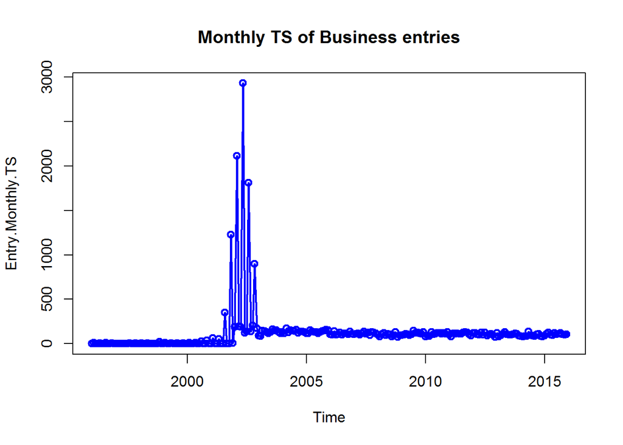

```r
Entry.Monthly.TS <- ts(Monthly.Entry.data$Businesses.entered,start=c(1996,1),frequency = 12)
#Entry.Monthly.TS <- ts(Monthly.Entry.data$Businesses.entered,frequency = 1)
plot(Entry.Monthly.TS,type="o",col="blue",lwd=2,main="Monthly TS of Business entries")
```

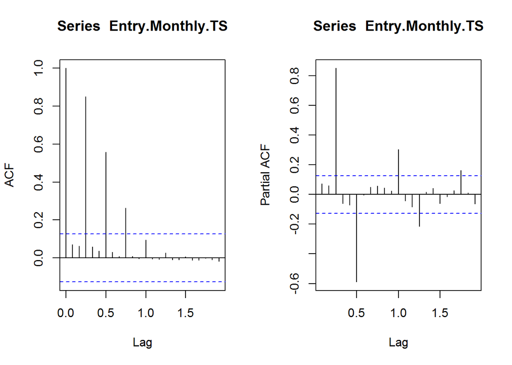

```r
par(mfrow=c(1,2))
acf(Entry.Monthly.TS)
pacf(Entry.Monthly.TS)
```

```r
adf.test(Entry.Monthly.TS)
```

```
##
##  Augmented Dickey-Fuller Test
##
## data:  Entry.Monthly.TS
## Dickey-Fuller = -4.8116, Lag order = 6, p-value = 0.01
## alternative hypothesis: stationary
```

```r
auto.arima(Entry.Monthly.TS)
```

```
## Series: Entry.Monthly.TS
## ARIMA(4,0,5)(0,0,1)[12] with non-zero mean
##
## Coefficients:
##          ar1      ar2     ar3      ar4      ma1     ma2     ma3      ma4
##       0.7873  -0.2918  0.7695  -0.4749  -0.9722  0.7056  0.2593  -0.5151
## s.e.  0.0761   0.0628  0.0598   0.0730   0.0616  0.0726  0.0713   0.0637
##          ma5     sma1  intercept
##       0.6522  -0.0228   117.3778
## s.e.  0.0534   0.0708    36.7762
##
## sigma^2 estimated as 12194:  log likelihood=-1473.86
## AIC=2971.72   AICc=2973.09   BIC=3013.48
```

Identify p,d,q,P,D,Q for Monthly Entry TS using fun.ts.holdout()

```r
options(warn=-1)
fun.ts.holdout(Entry.Monthly.TS,nperiod=12,nstart=1996,prange=0:4,drange=0:2,qrange=0:4,
               Prange=0:2,Drange=0:2,Qrange=0:2)
```

```
## $rsquares
##    [1] 0.0000000 0.2917126 0.2945751 0.3194170 0.3061673 0.0000000
##    [7] 0.2785208 0.3631548 0.3553285 0.3561731 0.2394267 0.2149805
##   [13] 0.2212407 0.2813327 0.2057587 0.2947371 0.2401469 0.2351411
##   [19] 0.3084817 0.3065395 0.0000000 0.2921809 0.3555203 0.3277913
##   [25] 0.3342860 0.2394267 0.2575275 0.3541152 0.3460768 0.3447079
##   [31] 0.3179877 0.2359505 0.3447687 0.3022711 0.3060630 0.2947371
##   [37] 0.2713629 0.3280463 0.3183321 0.4626782 0.2394267 0.2788393
##   [43] 0.3459376 0.3199721 0.3054348 0.3571823 0.2603474 0.4158031
##   [49] 0.3089743 0.3644863 0.3199356 0.3470558 0.3047130 0.3744299
##   [55] 0.3817257 0.3419460 0.1998249 0.3018301 0.2824477 0.2101997
##   [61] 0.3668169 0.3224387 0.3454508 0.2532245 0.2472594 0.3541296
##   [67] 0.3455547 0.3228758 0.3764064 0.3812670 0.3130997 0.3298760
##   [73] 0.3010050 0.3683433 0.3139271 0.2917126 0.2923842 0.2652347
##   [79] 0.3062579 0.3063948 0.2785208 0.2766645 0.3553188 0.3561232
```

[output cut: 2762 more lines]

```r
options(warn=0)
```

(p,q,d),(P,Q,D) parameters corresponding to the minimum error, at the index 1457, are (1,0,2),(1,0,2). R-squared value is 31.1%.

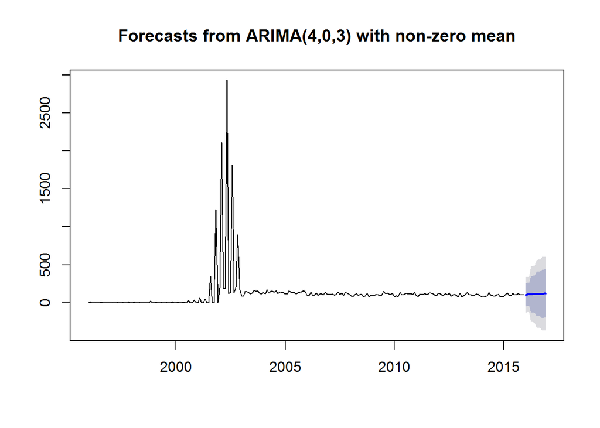

```r
Entry.arima.fit <- arima(Entry.Monthly.TS,order=c(4,0,3))
Entry.arima.forecast <- forecast(Entry.arima.fit,h=12)
plot(forecast(Entry.arima.forecast))
```

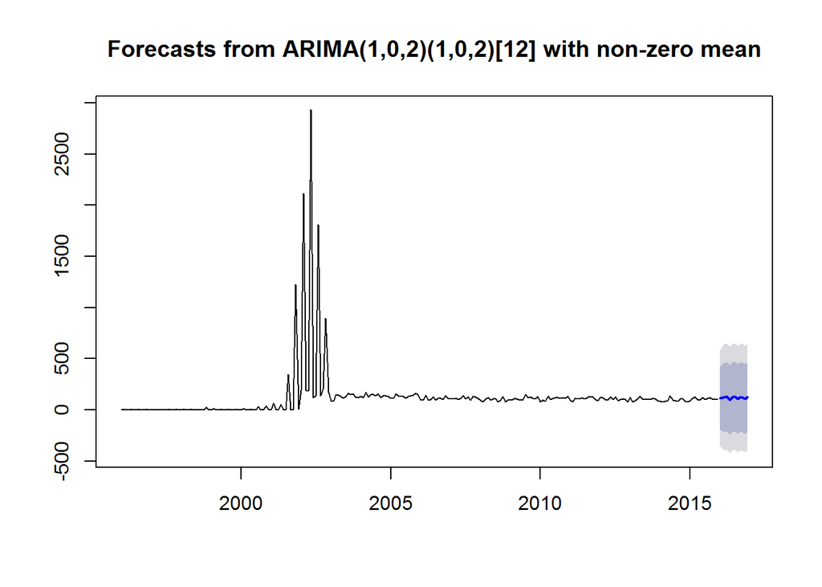

```r
Entry.func.fit <- arima(Entry.Monthly.TS,order=c(1,0,2),seasonal = list(order=c(1,0,2)))
Entry.func.forecast <- forecast(Entry.func.fit,h=12)
plot(forecast(Entry.func.forecast))
```

```r
cbind("Actual values"=Monthly.Entry.data$Businesses.entered[229:240],
      "Predicted values from auto arima"=Entry.arima.forecast$mean,
      "Predicted values from function"=Entry.func.forecast$mean)
```

```
##          Actual values Predicted values from auto arima
## Jan 2016            89                         104.2842
## Feb 2016           112                         108.8537
## Mar 2016           127                         110.2234
## Apr 2016           101                         110.9295
## May 2016            95                         114.6557
## Jun 2016           121                         115.4494
## Jul 2016           103                         115.7914
## Aug 2016           112                         118.3484
## Sep 2016           120                         118.4043
## Oct 2016           103                         118.2762
## Nov 2016           102                         119.8444
## Dec 2016           104                         119.3777
##          Predicted values from function
## Jan 2016                      112.74953
## Feb 2016                      119.03622
## Mar 2016                      124.58499
## Apr 2016                      126.38934
## May 2016                       96.07094
## Jun 2016                      127.45498
## Jul 2016                      125.15423
## Aug 2016                      107.73452
## Sep 2016                      126.71755
## Oct 2016                      122.93935
## Nov 2016                      107.73039
## Dec 2016                      126.75749
```

```r
errors.1 <- print(Monthly.Entry.data$Businesses.entered[229:240] -
                    Entry.arima.forecast$mean)
```

```
##             Jan        Feb        Mar        Apr        May        Jun
## 2016 -15.284235   3.146284  16.776580  -9.929528 -19.655743   5.550554
##             Jul        Aug        Sep        Oct        Nov        Dec
## 2016 -12.791435  -6.348421   1.595704 -15.276233 -17.844394 -15.377652
```

```r
SSE.arima <- print(sum(errors.1^2))
```

```
## [1] 2035.44
```

```r
errors.2 <- print(Monthly.Entry.data$Businesses.entered[229:240] -
                    Entry.func.forecast$mean)
```

```
##             Jan        Feb        Mar        Apr        May        Jun
## 2016 -23.749534  -7.036224   2.415012 -25.389344  -1.070941  -6.454984
##             Jul        Aug        Sep        Oct        Nov        Dec
## 2016 -22.154232   4.265481  -6.717550 -19.939353  -5.730392 -22.757487
```

```r
SSE.func <- print(sum(errors.2^2))
```

```
## [1] 2809.262
```

**Monthly Businesses Exit TS analysis**

```r
Monthly.Exit.data <- read.csv(file=paste(datapath,"ExitMonthlyData.csv",sep="/"),
                              header=TRUE,sep=",")
Monthly.Exit.data <- Monthly.Exit.data[1:228,]
head(Monthly.Exit.data)
```

```
##       Date No.of.Businesses.Exited
## 1 1/1/1997                       0
## 2 2/1/1997                       8
## 3 3/1/1997                       0
## 4 4/1/1997                       0
## 5 5/1/1997                       2
## 6 6/1/1997                       0
```

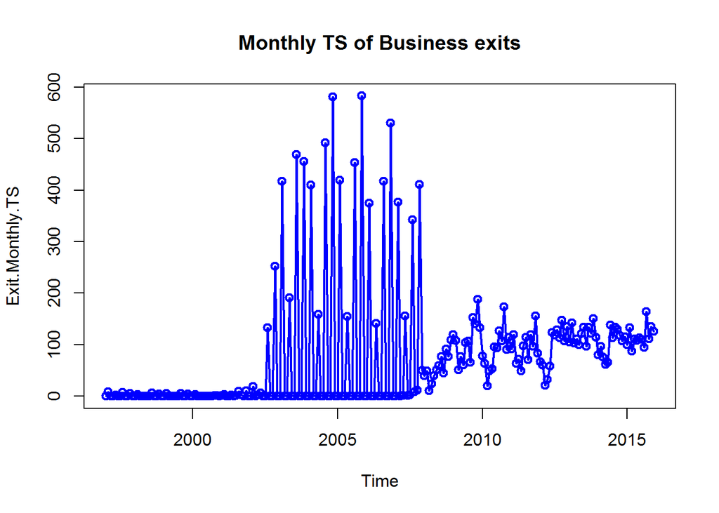

```r
Exit.Monthly.TS <- ts(Monthly.Exit.data$No.of.Businesses.Exited,start=c(1997,1),frequency = 12)
plot(Exit.Monthly.TS,type="o",col="blue",lwd=2,main="Monthly TS of Business exits")
```

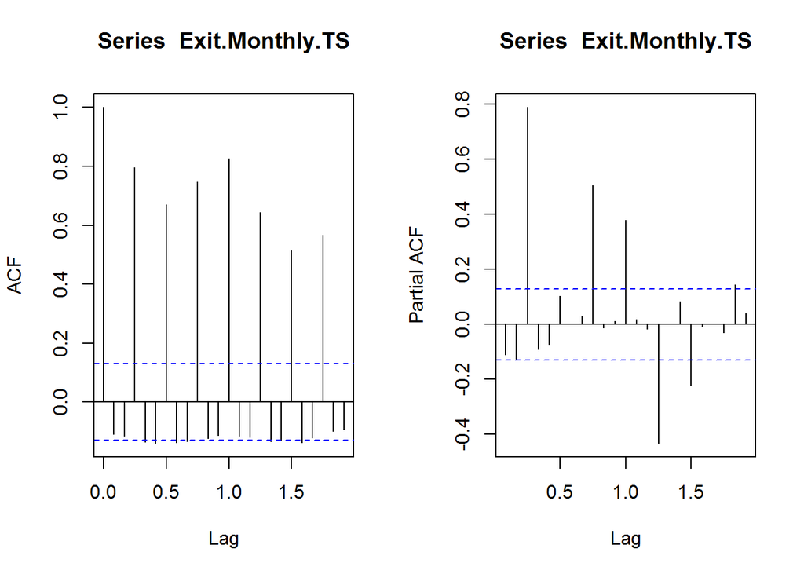

```r
par(mfrow=c(1,2))
acf(Exit.Monthly.TS)
pacf(Exit.Monthly.TS)
```

```r
adf.test(Exit.Monthly.TS)
```

```
##
##  Augmented Dickey-Fuller Test
##
## data:  Exit.Monthly.TS
## Dickey-Fuller = -4.0928, Lag order = 6, p-value = 0.01
## alternative hypothesis: stationary
```

```r
auto.arima(Exit.Monthly.TS)
```

```
## Series: Exit.Monthly.TS
## ARIMA(3,1,1)(1,0,2)[12]
##
## Coefficients:
##           ar1      ar2     ar3      ma1    sar1     sma1    sma2
##       -0.0368  -0.0233  0.6782  -0.9862  0.6504  -0.1405  0.3796
## s.e.   0.0532   0.0531  0.0528   0.0154  0.0628   0.0776  0.0707
##
## sigma^2 estimated as 2091:  log likelihood=-1197.21
## AIC=2410.41   AICc=2411.08   BIC=2437.81
```

Identify p,d,q,P,D,Q for Monthly Exit TS using fun.ts.holdout().

```r
options(warn=-1)
fun.ts.holdout(Exit.Monthly.TS,nperiod=12,nstart=1997,prange=0:4,drange=0:2,qrange=0:4,
               Prange=0:2,Drange=0:2,Qrange=0:2)
```

```
## $rsquares
##    [1] 0.0000000 0.3205202 0.2002997 0.1964396 0.1922414 0.0000000
##    [7] 0.3705258 0.2057732 0.1974851 0.2032175 0.2436095 0.2673939
##   [13] 0.2455871 0.2261475 0.2593593 0.3031257 0.3074761 0.2011494
##   [19] 0.1929320 0.1931026 0.0000000 0.3536145 0.1974496 0.2011444
##   [25] 0.1718737 0.2436095 0.3391956 0.1969955 0.1906265 0.1944429
##   [31] 0.2571537 0.2919687 0.1752716 0.1939441 0.2088955 0.3031257
##   [37] 0.3152438 0.2077554 0.1726702 0.1484367 0.2436095 0.3769045
##   [43] 0.1908857 0.2356239 0.1880101 0.2841842 0.2371344 0.2506616
##   [49] 0.1297810 0.1619324 0.2841462 0.2981926 0.1295870 0.1598037
##   [55] 0.1475746 0.3541936 0.2931373 0.2001444 0.1662654 0.1580377
##   [61] 0.2756162 0.2277267 0.2131589 0.1651891 0.1485266 0.2813618
##   [67] 0.3531403 0.1630272 0.1478272 0.1336557 0.2821638 0.2689830
##   [73] 0.1307747 0.1565841 0.2113134 0.3205202 0.3172961 0.1965047
##   [79] 0.1922632 0.1936663 0.3705258 0.3754128 0.1974889 0.2032771
```

[output cut: 2762 more lines]

```r
options(warn=0)
```

(p,q,d),(P,Q,D) parameters corresponding to the minimum error, at the index 697, are (1,1,1),(0,0,1). R-squared value is 17.09%.

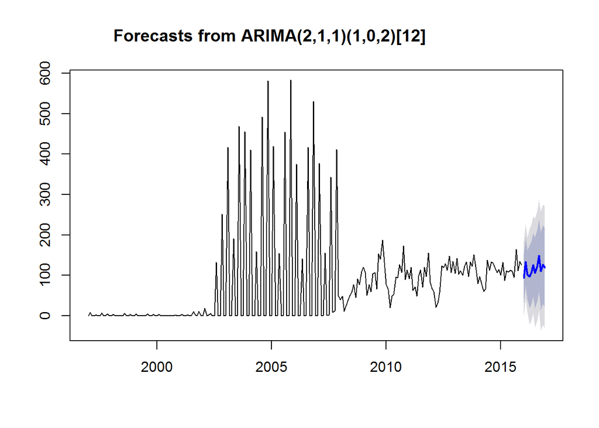

```r
Exit.arima.fit <- arima(Exit.Monthly.TS,order=c(2,1,1),seasonal = list(order=c(1,0,2)))
Exit.arima.forecast <- forecast(Exit.arima.fit,h=12)
plot(forecast(Exit.arima.forecast))
```

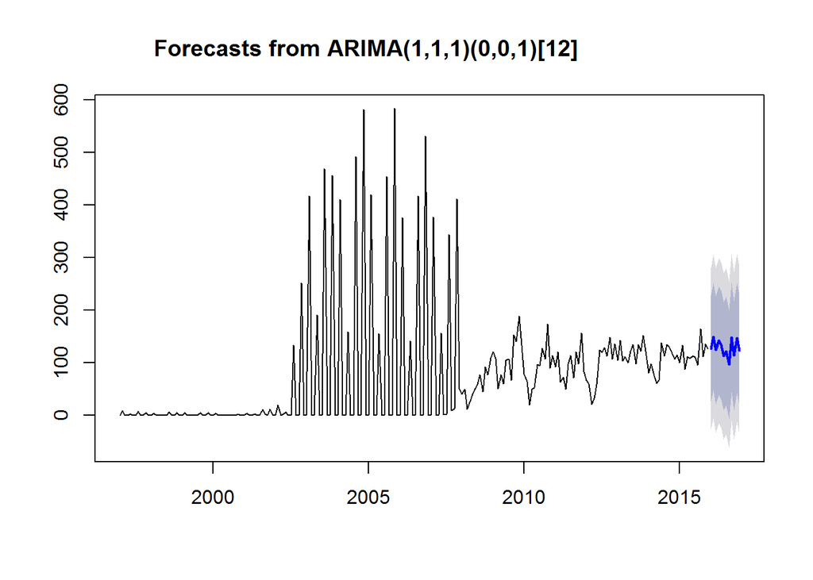

```r
Exit.func.fit <- arima(Exit.Monthly.TS,order=c(1,1,1),seasonal = list(order=c(0,0,1)))
Exit.func.forecast <- forecast(Exit.func.fit,h=12)
plot(forecast(Exit.func.forecast))
```

```r
cbind("Actual values"=Monthly.Exit.data$No.of.Businesses.Exited[217:228],
      "Predicted values from auto arima"=Exit.arima.forecast$mean,
      "Predicted values from function"=Exit.func.forecast$mean)
```

```
##          Actual values Predicted values from auto arima
## Jan 2016           100                         93.39884
## Feb 2016           133                        133.53812
## Mar 2016            87                        101.52451
## Apr 2016           111                         96.84273
## May 2016           108                        106.82071
## Jun 2016           113                        125.96919
## Jul 2016           110                        106.04009
## Aug 2016            95                        123.04279
## Sep 2016           164                        149.51130
## Oct 2016           111                        110.88163
## Nov 2016           135                        126.97246
## Dec 2016           126                        119.27452
##          Predicted values from function
## Jan 2016                      126.46147
## Feb 2016                      149.62152
## Mar 2016                      123.67450
## Apr 2016                      142.04689
## May 2016                      133.10827
## Jun 2016                      112.11746
## Jul 2016                      121.79208
## Aug 2016                       96.17119
## Sep 2016                      148.18031
## Oct 2016                      113.08079
## Nov 2016                      146.69449
## Dec 2016                      122.94579
```

```r
errors.1 <- print(Monthly.Exit.data$No.of.Businesses.Exited[217:228] -
                    Exit.arima.forecast$mean)
```

```
##              Jan         Feb         Mar         Apr         May
## 2016   6.6011624  -0.5381158 -14.5245119  14.1572713   1.1792865
##              Jun         Jul         Aug         Sep         Oct
## 2016 -12.9691897   3.9599100 -28.0427867  14.4886969   0.1183744
##              Nov         Dec
## 2016   8.0275433   6.7254784
```

```r
SSE.arima <- print(sum(errors.1^2))
```

```
## [1] 1746.534
```

```r
errors.2 <- print(Monthly.Exit.data$No.of.Businesses.Exited[217:228] -
                    Exit.func.forecast$mean)
```

```
##              Jan         Feb         Mar         Apr         May
## 2016 -26.4614672 -16.6215189 -36.6744985 -31.0468878 -25.1082715
##              Jun         Jul         Aug         Sep         Oct
## 2016   0.8825363 -11.7920783  -1.1711897  15.8196872  -2.0807865
##              Nov         Dec
## 2016 -11.6944863   3.0542107
```

```r
SSE.func <- print(sum(errors.2^2))
```

```
## [1] 4457.723
```

**Monthly Active Businesses TS analysis**

```r
Monthly.Active.data <- read.csv(file=paste(datapath,"ActiveMonthlyData.csv",
                                           sep="/"),header=TRUE,sep=",")
Monthly.Active.data <- Monthly.Active.data[1:240,]
head(Monthly.Active.data)
```

```
##         Date Businesses.Active
## 1 01/01/1996                 0
## 2 02/01/1996                 9
## 3 03/01/1996                 9
## 4 04/01/1996                 9
## 5 05/01/1996                14
## 6 06/01/1996                14
```

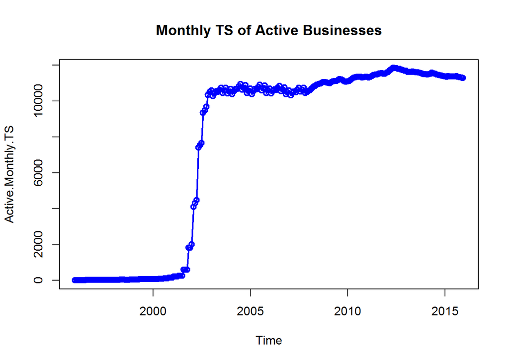

```r
Active.Monthly.TS <- ts(Monthly.Active.data$Businesses.Active,start=c(1996,1),frequency = 12)
plot(Active.Monthly.TS,type="o",col="blue",lwd=2,main="Monthly TS of Active Businesses")
```

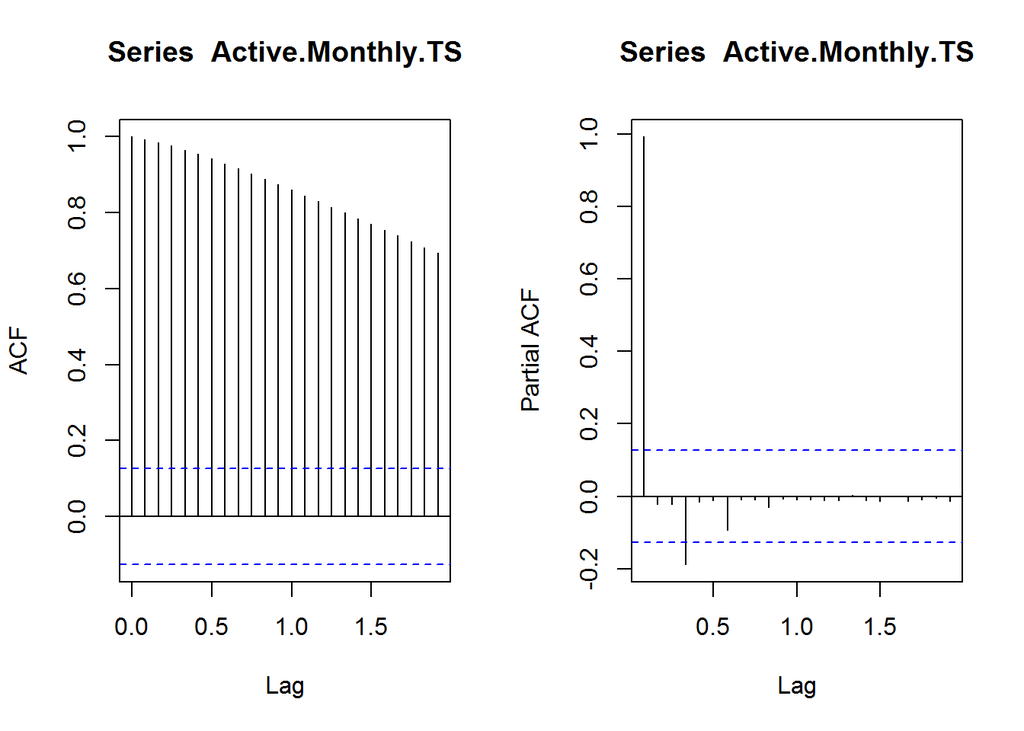

```r
par(mfrow=c(1,2))
acf(Active.Monthly.TS)
pacf(Active.Monthly.TS)
```

```r
adf.test(Active.Monthly.TS)
```

```
##
##  Augmented Dickey-Fuller Test
##
## data:  Active.Monthly.TS
## Dickey-Fuller = -1.3008, Lag order = 6, p-value = 0.8699
## alternative hypothesis: stationary
```

```r
auto.arima(Active.Monthly.TS)
```

```
## Series: Active.Monthly.TS
## ARIMA(3,1,3)
##
## Coefficients:
##          ar1      ar2     ar3     ma1     ma2     ma3
##       0.0086  -0.0032  0.7311  0.0324  0.0566  0.3575
## s.e.  0.0505   0.0518  0.0459  0.0755  0.0822  0.0492
##
## sigma^2 estimated as 23088:  log likelihood=-1541.8
## AIC=3097.6   AICc=3098.08   BIC=3121.94
```

Identify p,d,q,P,D,Q for Monthly Active TS

```r
options(warn=-1)
fun.ts.holdout(Active.Monthly.TS/100,nperiod=12,nstart=1996,prange=0:4,drange=0:2,qrange=0:4,
               Prange=0:2,Drange=0:2,Qrange=0:2)
```

```
## $rsquares
##    [1] 0.0000000 0.7557248 0.7557255 0.7564596 0.6511939 0.0000000
##    [7] 0.3170490 0.3458480 0.4654140 0.4693762 0.7581848 0.7461810
##   [13] 0.5460011 0.5503155 0.5695771 0.2930613 0.7540894 0.7462953
##   [19] 0.7460802 0.6349992 0.0000000 0.7252216 0.7043519 0.4680014
##   [25] 0.4869012 0.7581848 0.7094255 0.5499430 0.6189729 0.6532697
##   [31] 0.3851807 0.7453071 0.7441314 0.7539208 0.5449085 0.2930613
##   [37] 0.6734850 0.6580462 0.5606784 0.5948367 0.7581848 0.7571473
##   [43] 0.6420563 0.6812208 0.6656982 0.4555759 0.6664523 0.6816325
##   [49] 0.3570675 0.4344952 0.3694481 0.2620571 0.1860877 0.5746591
##   [55] 0.5718374 0.7143030 0.7552162 0.6458597 0.6483135 0.6581918
##   [61] 0.5230555 0.7170228 0.7166069 0.6446131 0.4662319 0.2223943
##   [67] 0.2215014 0.2093552 0.4742936 0.4741495 0.5186092 0.4907662
##   [73] 0.5422386 0.6530606 0.6577459 0.7557248 0.7718294 0.7565302
##   [79] 0.5021005 0.5257556 0.3170490 0.3083249 0.4544352 0.4693762
```

[output cut: 2762 more lines]

```r
options(warn=0)
```

(p,q,d),(P,Q,D) parameters corresponding to the minimum error, at the index 137, are (1,0,4),(1,0,0). R-squared value is 65.02%.

**Forecast No of active business for 2015 using parameters returned from auto.arima()**

[figure not shown]

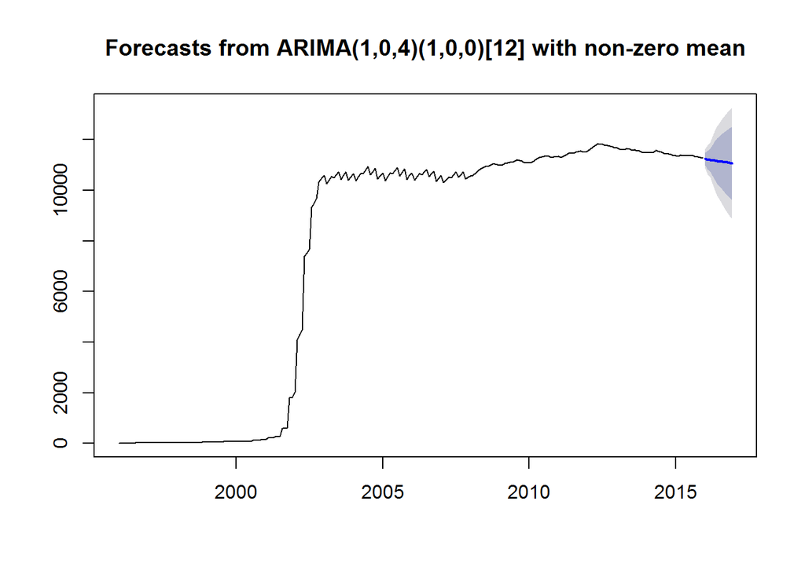

```r
Active.func.fit <- arima(Active.Monthly.TS,order=c(1,0,4),seasonal = list(order=c(1,0,0)))
Active.func.forecast <- forecast(Active.func.fit,h=12)
plot(forecast(Active.func.forecast))
```

```r
cbind("Actual values"=Monthly.Active.data$Businesses.Active[229:240],
      "Predicted values from auto arima"=Active.arima.forecast$mean,
      "Predicted values from function"=Active.func.forecast$mean)
```

```
##          Actual values Predicted values from auto arima
## Jan 2016         11366                         11261.60
## Feb 2016         11345                         11219.74
## Mar 2016         11385                         11212.00
## Apr 2016         11375                         11204.46
## May 2016         11362                         11173.82
## Jun 2016         11370                         11167.92
## Jul 2016         11363                         11162.46
## Aug 2016         11380                         11140.03
## Sep 2016         11336                         11135.54
## Oct 2016         11327                         11131.59
## Nov 2016         11294                         11115.17
## Dec 2016         11272                         11111.76
##          Predicted values from function
## Jan 2016                       11253.81
## Feb 2016                       11201.43
## Mar 2016                       11198.60
## Apr 2016                       11189.61
## May 2016                       11174.10
## Jun 2016                       11162.16
## Jul 2016                       11147.75
## Aug 2016                       11137.42
## Sep 2016                       11116.86
## Oct 2016                       11102.24
## Nov 2016                       11083.63
## Dec 2016                       11066.91
```

```r
errors.1 <- print(Monthly.Active.data$Businesses.Active[229:240] -
                    Active.arima.forecast$mean)
```

```
##           Jan      Feb      Mar      Apr      May      Jun      Jul
## 2016 104.3972 125.2611 173.0043 170.5362 188.1811 202.0800 200.5377
##           Aug      Sep      Oct      Nov      Dec
## 2016 239.9690 200.4559 195.4117 178.8299 160.2381
```

```r
SSE.arima <- print(sum(errors.1^2))
```

```
## [1] 395675.8
```

```r
errors.2 <- print(Monthly.Active.data$Businesses.Active[229:240] -
                    Active.func.forecast$mean)
```

```
##           Jan      Feb      Mar      Apr      May      Jun      Jul
## 2016 112.1885 143.5726 186.4013 185.3872 187.9004 207.8353 215.2504
##           Aug      Sep      Oct      Nov      Dec
## 2016 242.5826 219.1365 224.7566 210.3721 205.0930
```

```r
SSE.func <- print(sum(errors.2^2))
```

```
## [1] 470850.3
```